# TMDB Box Office Prediction

Kaggle Competition

### Initial setup

#### Loading the necessary packages

```r
library(tidyverse)
library(readr)
library(lubridate)
library(ggplot2)
library(plotly)
library(randomForest)
library(stringi)
library(gbm)
```

#### Loading the train and test datasets

```r
train.data <- read.csv("train.csv", na.strings = c("", 0, '[]', '#N/A'))

test.data <- read.csv('test.csv', na.strings = c("", 0, '[]', '#N/A'))

dim(train.data)
```

```
## [1] 3000   23
```

```r
dim(test.data)
```

```
## [1] 4398   22
```

#### Combining the test and train datasets for analysis

```r
test.data$revenue <- NA
complete.data <- rbind(train.data, test.data)

glimpse(complete.data)
```

```
## Observations: 7,398
## Variables: 23
## $ ï..id                 <int> 1, 2, 3, 4, 5, 6, 7, 8, 9, 10, 11, 12, 13, 14...
## $ belongs_to_collection <fct> "[{'id': 313576, 'name': 'Hot Tub Time Machin...
## $ budget                <int> 14000000, 40000000, 3300000, 1200000, NA, 800...
## $ genres                <fct> "[{'id': 35, 'name': 'Comedy'}]", "[{'id': 35...
## $ homepage              <fct> NA, NA, http://sonyclassics.com/whiplash/, ht...
## $ imdb_id               <fct> tt2637294, tt0368933, tt2582802, tt1821480, t...
## $ original_language     <fct> en, en, en, hi, ko, en, en, en, en, en, en, e...
## $ original_title        <fct> Hot Tub Time Machine 2, The Princess Diaries ...
## $ overview              <fct> "When Lou, who has become the \"father of the...
## $ popularity            <dbl> 6.575393, 8.248895, 64.299990, 3.174936, 1.14...
## $ poster_path           <fct> /tQtWuwvMf0hCc2QR2tkolwl7c3c.jpg, /w9Z7A0GHEh...
## $ production_companies  <fct> "[{'name': 'Paramount Pictures', 'id': 4}, {'...
## $ production_countries  <fct> "[{'iso_3166_1': 'US', 'name': 'United States...
## $ release_date          <fct> 2/20/2015, 8/6/2004, 10/10/2014, 3/9/2012, 2/...
## $ runtime               <int> 93, 113, 105, 122, 118, 83, 92, 84, 100, 91, ...
## $ spoken_languages      <fct> "[{'iso_639_1': 'en', 'name': 'English'}]", "...
## $ status                <fct> Released, Released, Released, Released, Relea...
## $ tagline               <fct> "The Laws of Space and Time are About to be V...
## $ title                 <fct> Hot Tub Time Machine 2, The Princess Diaries ...
## $ Keywords              <fct> "[{'id': 4379, 'name': 'time travel'}, {'id':...
## $ cast                  <fct> "[{'cast_id': 4, 'character': 'Lou', 'credit_...
## $ crew                  <fct> "[{'credit_id': '59ac067c92514107af02c8c8', '...
## $ revenue               <int> 12314651, 95149435, 13092000, 16000000, 39239...
```

```r
colnames(complete.data)[1] <- gsub('^...','',colnames(complete.data)[1])
```

Based on the initial glimpse of the dataset, we notice:

- Columns like `tmdb_id`, `poster_path` are not relevant for this analysis
- Columns like `genres`, `production_companies`, `Keywords`, `cast` need to be cleaned as they have multiple information stored in single cell
- Columns like `tagline`, `homepage` can have indicator flags associated

### Feature Engineering

#### Irrelevant Features

**Dropping columns imdb_id, poster_path from our analytical dataset**

```r
complete.data <- complete.data %>%
                    select(-c("imdb_id",
                              "poster_path"))
```

#### Indicator Variables

Considering the nature of variables: `homepage`, `tagline`, `overview`, `belongs_to_collection`, we will be creating indicator variables for these

```r
complete.data <- complete.data %>%
                    mutate(has_homepage = ifelse(is.na(homepage),"no" , "yes"),
                           has_overview = ifelse(is.na(overview), "no" , "yes"),
                           has_tagline = ifelse(is.na(tagline), "no", "yes"),
                           part_of_collection = ifelse(is.na(belongs_to_collection), "no", "yes"))

#Dropping the original columns
complete.data <- complete.data %>%
                    select(-c("homepage", "overview", "tagline", "belongs_to_collection"))
```

Cleaning up following columns by creating derived variables

- genres
- production_companies
- production_countries
- spoken_languages
- Keywords
- cast
- crew

#### Genres

- Creating a new variable `total_genres` to store the count of total number of genres for each movie
- Creating indicator variables corresponding to each genre

```r
#Counting the total number of genres for each movie
complete.data$total_genres <- str_count(complete.data$genres, pattern = 'name')

#Flagging indicators variables as 1 or 0 if the movie is of a particular genre or not
complete.data$genre_adv <-  ifelse(stri_detect_fixed(complete.data$genres, 'Adventure'),1, 0)
complete.data$genre_ani <-  ifelse(stri_detect_fixed(complete.data$genres, 'Animation'),1, 0)
complete.data$genre_fam <-  ifelse(stri_detect_fixed(complete.data$genres, 'Family'),1, 0)
complete.data$genre_fty <-  ifelse(stri_detect_fixed(complete.data$genres, 'Fantasy'),1, 0)
complete.data$genre_hor <-  ifelse(stri_detect_fixed(complete.data$genres, 'Horror'),1, 0)
complete.data$genre_sci <-  ifelse(stri_detect_fixed(complete.data$genres, 'Science Fiction'),1, 0)
complete.data$genre_com <-  ifelse(stri_detect_fixed(complete.data$genres, 'Comedy'),1, 0)
complete.data$genre_rom <-  ifelse(stri_detect_fixed(complete.data$genres, 'Romance'),1, 0)
complete.data$genre_dra <-  ifelse(stri_detect_fixed(complete.data$genres, 'Drama'),1, 0)
complete.data$genre_war <-  ifelse(stri_detect_fixed(complete.data$genres, 'War'),1, 0)
complete.data$genre_mys <-  ifelse(stri_detect_fixed(complete.data$genres, 'Mystery'),1, 0)
complete.data$genre_his <-  ifelse(stri_detect_fixed(complete.data$genres, 'History'),1, 0)
complete.data$genre_doc <-  ifelse(stri_detect_fixed(complete.data$genres, 'Documentary'),1, 0)
complete.data$genre_thl <-  ifelse(stri_detect_fixed(complete.data$genres, 'Thriller'),1, 0)
complete.data$genre_cri <-  ifelse(stri_detect_fixed(complete.data$genres, 'Crime'),1, 0)
complete.data$genre_act <-  ifelse(stri_detect_fixed(complete.data$genres, 'Action'),1, 0)
complete.data$genre_wes <-  ifelse(stri_detect_fixed(complete.data$genres, 'Western'),1, 0)
complete.data$genre_mus <-  ifelse(stri_detect_fixed(complete.data$genres, 'Music'),1, 0)
complete.data$genre_fgn <-  ifelse(stri_detect_fixed(complete.data$genres, 'Foreign'),1, 0)
complete.data$genre_tvm <-  ifelse(stri_detect_fixed(complete.data$genres, 'TV Movie'),1, 0)
```

#### Production Companies

- Creating a new variable `total_prod_comp` to store the count of total number of production companies associated with a movie
- Identifying the main production company of movies: `main_prod_comp`

```r
##Creating variable for number of production companies
complete.data$tot_prod_comp <- str_count(complete.data$production_companies, pattern = 'name')

#Extracting the main prodcution company
for (i in 1:length(complete.data$production_companies))
{
  complete.data$main_prod_comp[i] <- substr(complete.data$production_companies[i],  str_locate(complete.data$production_companies[i],"name")[,1]+8, (str_locate_all(complete.data$production_companies[i],"'")[[1]][4])-1)
}
```

#### Production Countries

- Creating a new variable `total_prod_country` to store the count of total number of production countries associated with a movie
- Identifying the main production country of movies: `main_prod_country`

```r
##Creating variable for number of production countries
complete.data$tot_prod_country <- str_count(complete.data$production_countries, pattern = 'name')

#Extracting the main prodcution country
for (i in 1:length(complete.data$production_countries))
{
  complete.data$main_prod_country[i] <- substr(complete.data$production_countries[i], str_locate(complete.data$production_countries[i],"name")[,1]+8, (str_locate_all(complete.data$production_countries[i],"'")[[1]][8])-1)
}
```

#### Spoken Languages

Creating variable `tot_language` to store the count of total spoken languages

```r
complete.data$tot_language <- str_count(complete.data$spoken_languages, pattern = 'name')
```

#### Keywords

```r
##Creating variable for number of keywords associated
complete.data$tot_keywords <- str_count(complete.data$Keywords, pattern = 'name')
```

#### Cast

Creating variables `tot_cast`, `tot_female_cast` and `tot_male_cast` to store count of total cast, total female cast and total male cast respectively

```r
complete.data$tot_cast <- str_count(complete.data$cast, pattern = 'name')
complete.data$tot_female_cast <- str_count(complete.data$cast, pattern = "'gender': 1")
complete.data$tot_male_cast <- str_count(complete.data$cast, pattern = "'gender': 2")
```

#### Crew

Creating variables `tot_crew`, `tot_female_crew` and `tot_male_crew` to store count of total crew, total female crew and total male crew respectively

```r
complete.data$tot_crew <- str_count(complete.data$crew, pattern = 'name')
complete.data$tot_female_crew <- str_count(complete.data$crew, pattern = "'gender': 1")
complete.data$tot_male_crew <- str_count(complete.data$crew, pattern = "'gender': 2")
```

Dropping original variables:

```r
analysis_data <- complete.data %>%
                  select(-c("genres",
                            "production_companies",
                            "spoken_languages",
                            "Keywords",
                            "cast",
                            "crew"))
```

#### Status

```r
table((analysis_data$status))
```

```
##
##        Released         Rumored Post Production
##            7385               6               5
```

```r
#Since majority of the movies have same status, removing the column from our analysis

analysis_data$status <- NULL
```

#### Original title and title

Dropping these columns

```r
analysis_data$original_title <- NULL
analysis_data$title <- NULL
```

#### Release date

Determining the day, month, year and quarter when the movie was released. Also, flagging movie whether it was released on a weekend(Friday/Saturday/Sunday) or not

```r
analysis_data$weekday <- weekdays(as.Date(analysis_data$release_date,format="%m/%d/%y"))

analysis_data$is_weekend <- ifelse(analysis_data$weekday %in% c("Friday","Saturday","Sunday"), "yes","no")

analysis_data$release_month <- as.factor(month(as.Date(analysis_data$release_date, format = "%m/%d/%y")))

analysis_data$release_year <- year(as.Date(analysis_data$release_date, format = "%m/%d/%y"))

analysis_data$release_quarter <- as.factor(quarter(as.Date(analysis_data$release_date, format = "%m/%d/%y")))

##Dropping release_date
analysis_data$release_date <- NULL
```

#### Original Language

Creating a variable to categorize movie as English or non-English

```r
table(analysis_data$original_language)
```

```
##
##   ar   bn   cn   cs   da   de   el   en   es   fa   fi   fr   he   hi   hu   id
##    1    3   41    3   17   49    3 6351   95    5    4  199    6  118    4    3
##   it   ja   ko   ml   mr   nb   nl   no   pl   pt   ro   ru   sr   sv   ta   te
##   56   90   49   12    1    1   11    5    5   13    9  109    3   20   31    9
##   tr   ur   vi   zh   af   bm   ca   is   ka   kn   th   xx
##    9    2    1   46    1    2    1    1    1    1    5    2
```

```r
analysis_data$language[analysis_data$original_language == 'en'] <- "English"
analysis_data$language[is.na(analysis_data$language == 'en')] <- "Non-English"

analysis_data$original_language <- NULL
```

### Exploratory Data Analysis & Missing Values treatment

**Univariate analysis and Feature Selection**

**Understanding the relationship between each predictor variable and the response variable `revenue`**

```r
summary(analysis_data$budget)
```

```
##      Min.   1st Qu.    Median      Mean   3rd Qu.      Max.      NA's
##         1   5053316  17000000  31108016  40000000 380000000      2023
```

```r
##Imputing the missing values of *budget* with the median budget value
analysis_data$budget[is.na(analysis_data$budget)] <- median(analysis_data$budget, na.rm = T)
```

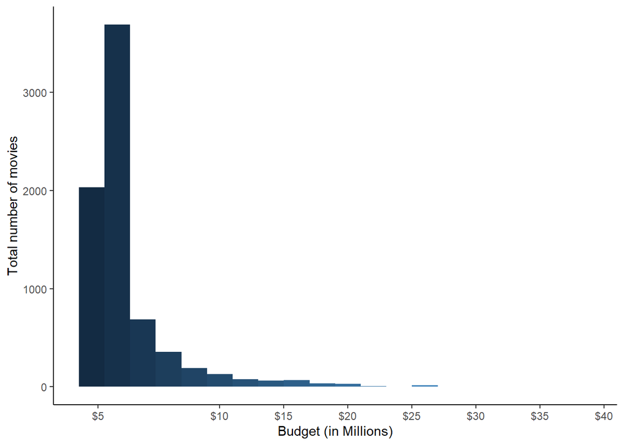

```r
ggplot(data = analysis_data, aes(x = budget, fill = ..x..))+
  geom_histogram(bins = 20) +
    theme_classic() +
      scale_x_continuous(breaks = c(5000000,100000000,150000000, 200000000,250000000, 300000000,350000000,400000000),
                         labels = c('$5', '$10','$15' ,'$20', '$25','$30', '$35','$40')) +
        theme(legend.position = 'none') +
          ylab("Total number of movies") +
            xlab("Budget (in Millions)")
```

```r
#+
#              title("Frequency distribution of Budget")
```

Relationship between `revenue` and `budget`

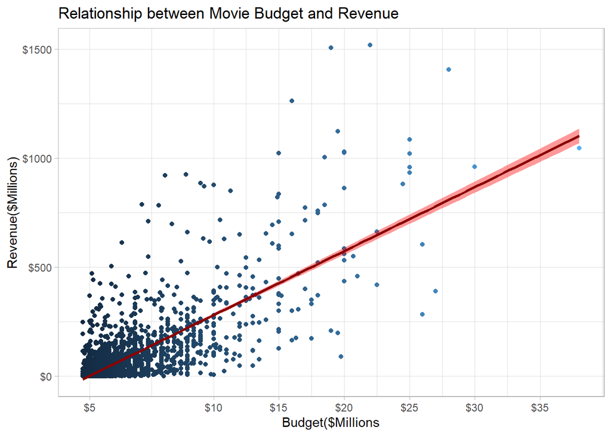

```r
ggplot(data = analysis_data[1:3000,], aes(x= budget, y = revenue, color = budget))+
  geom_point() +
      geom_smooth(method = "lm", color = "darkred", fill = "red") +
        theme_light() +
          scale_x_continuous(breaks = c(5000000,100000000,150000000, 200000000,250000000, 300000000,350000000,400000000),
                              labels = c('$5', '$10','$15' ,'$20', '$25','$30', '$35','$40')) +
            scale_y_continuous(breaks = c(0, 500000000, 1000000000, 1500000000),
                               labels = c('$0', '$500', '$1000', '$1500')) +
              theme(legend.position = 'none') +
                  labs(title = "Relationship between Movie Budget and Revenue",
                       x = "Budget($Millions",
                       y = "Revenue($Millions)")
```

```r
# ggplot(data = analysis_data, aes(x = revenue, fill = ..x..))+
#   geom_histogram() +
#     theme_classic()
```

- **Popularity**

```r
sum(is.na(analysis_data$popularity))
```

```
## [1] 0
```